# Linear Regression in R - Exercise 1

Macarena L. Fernandez Carro

2024-07-18

In this exercise, we are going to learn how to upload a dataset to R and run some computation to obtain the values of $\hat{B_{0}}$ and $\hat{B_{1}}$

The Ordinary Least Squares approach finds estimates of $\hat{B_{0}}$ and $\hat{B_{1}}$ that best fit the data.

The fitted equation is defined as:

$$\begin{align*}
y = &\hat{B_{0}} + \hat{B_{1}}x
\end{align*}$$

Therefore, for each observed response $y_{i}$, with a corresponding predictor value of $x_{i}$, the goal is to obtain a fitted value according to the previous formula that minimizes the sum of the squared distances of each response.

The distance is called the SSE, the error sum of squares and is defined as:

$$\begin{align*}
SSE = \sum_{i=1}^{n}(y_{i} - \hat{y_{i}})^2
\end{align*}$$

From the SSE, the values of $\S_{xx}$ and $\S_{xy}$ and $\S_{yy}$ can be derived. These values relate to the Pearson’s Correlation Coeficient and are defined as follow:

$$\begin{align*}
S_{xx} = \sum(x - \overline{x})^2 = \sum{x^{2}} - \frac{(\sum{x})^2}{n}
\end{align*}$$

$$\begin{align*}
S_{xy} = \sum(x - \overline{x})(y-\overline{y}) = \sum{xy} -
\frac{(\sum{x})(\sum{y})}{n}
\end{align*}$$

These formulas gives the estimates of $B_{0}$ and $B_{1}$ as follow:

$$\begin{align*}
\hat{B_{1}} = \frac{\sum_{i=1}^{n}(x-\overline{x})(y -
\overline{y})}{\sum_{i=1}^{n}(x-\overline{x})^{2}} =
\frac{S_{xy}}{S_{xx}}
\end{align*}$$

$$\begin{align*}
\hat{B_{0}} = \overline{y}-\hat{B}\overline{x} =
\frac{\sum_{i=1}^{n}y_{i}}{n}-\hat{B_{1}}\frac{\sum_{i=1}^{n}x_{i}}{n}
\end{align*}$$

The SSE can then be written regardgin the above:

$$\begin{align*}
SSE = S_{yy}-\frac{S^{2}_{xy}}{S_{xx}}
\end{align*}$$

The Mean Square Error (MSE) is then the SSE divided by (n-2) since there are two estimated parameters.

$$\begin{align*}
MSE = \frac{SSE}{n-2} =
\frac{\sum_{i=1}^{n}(y_{i}-\hat{y_{i}})}{n-2}=\frac{S_{yy}-\frac{S^{2}_{xy}}{S_{xx}}}{n-2}
\end{align*}$$

The Standard Error of $B_{1}$ and $B_{0}$ can then be found with the standard error.

$$\begin{align*}
se(B_{1}) = \frac{\sqrt{MSE}}{\sqrt{S_{xx}}}
\end{align*}$$

$$\begin{align*}
se(B_{0})=\frac{\sqrt{MSE}}{\sqrt{n}\sqrt{1+\frac{\overline{x^{2}}}{\sum\frac{x-\overline{x^{2}}}{n}}}}
\end{align*}$$

The t-values of $B_{1}$and $B_{0}$ can then be found with the standard errors:

$$\begin{align*}
t = \frac{B_{1}-B}{se(B_{1})}
\end{align*}$$

In the case of linear regression, the B that is substracted from the coefficient is set to 0.

The t-value of $B_{0}$ can also be found with the same equation by replacing $B_{1}$ for $B_{0}$. With the t-values of the coefficients, the p-values can then be computed. There are $n-2$ degreesof freedom since there are two parameters in the model. The p-value is multiplied by two as it is a two-tailed test (the values can be positive and negative).

```r
library(tidyverse)
data <- read.csv("Ex1data.csv",
                 header = TRUE,
                 sep = ",")

x <- data$x
y <- data$y
```

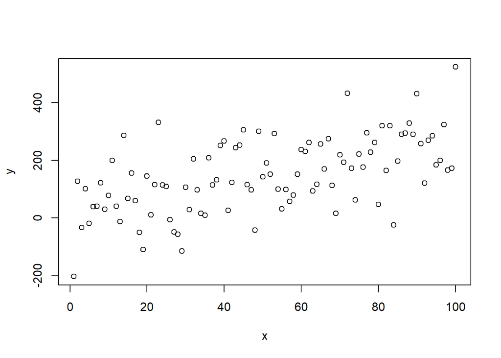

```r
plot(x,y)
```

## QUIZ QUESTIONS

1. What is the mean of x and y?

```r
mean_x <- mean(x)
mean_y <- mean(y)

mean(x)
```

```
## [1] 50.5
```

```r
mean(y)
```

```
## [1] 148.4311
```

```r
n <- length(data)
SXX <- 100*sum(x^2)-(sum(x))^2
SXY <- 100*sum(x*y)-sum(x)*sum(y)

print(SXX)
```

```
## [1] 8332500
```

```r
print(SXY)
```

```
## [1] 20902952
```

3. Find the values of $\hat{B_{0}}$ and $\hat{B_{1}}$

```r
B1 <- SXY/SXX
B0 <- mean(y) - B1*mean(x)

print(B0)
```

```
## [1] 21.74659
```

```r
print(B1)
```

```
## [1] 2.508605
```

### SUMMARY

The function below collects all the equations and steps above to perform simple linear regression. There’s no practical reason to use this over the standard lm() function, however, it may provide some further understanding of how linear regression is performed in R.

```r
simple.linear.coef <- function(x, y) {
  # Find length of x to get sample size. Assuming x and y have the same sample size.
  n <- length(x)
  # Calculate the error statistics Sxx, Syy, and Sxy
  sxx <- sum(x^2) - sum(x)^2 / n
  syy <- sum(y^2) - sum(y)^2 / n
  sxy <- sum(x * y) - (sum(x) * sum(y)) / n
  # Coefficients beta0 and beta1
  b1 <- sxy / sxx
  b0 <- mean(y) - b1 * mean(x)
  # Sum of standard error and Mean Standard Error
  sse <- syy - sxy^2 / sxx
  mse <- sse / (n - 2)
  # Standard error beta0 and beta1
  b1.err <- sqrt(mse) / sqrt(sxx)
  b0.err <- sqrt(mse) / sqrt(n) * sqrt(1 + (mean(x)^2 / (sum((x - mean(x))^2) / n)))
  # beta0 and beta1 t-values
  b0.t <- (b0 - 0) / b0.err
  b1.t <- (b1 - 0) / b1.err
  # p-values of beta0 and beta1
  b0.p <- 2 * pt(b0.t, df = n - 2)
  b1.p <- 2 * pt(b1.t, df = n - 2, lower.tail = FALSE)
  # Coefficient of determination R-squared
  r2 <- (syy - sse) /syy
  # R-squared adjusted
  r2.adj <- r2 - (1 - r2) * ((2 - 1) / (length(y) - 2))

  rsquare <- paste('Multiple R-squared: ', round(r2, 4), ', Adjusted R-squared: ', round(r2.adj, 4))

  coeffs <- data.frame(cbind(c(b0, b1), c(b0.err, b1.err), c(b0.t, b1.t), c(b0.p, b1.p)))
  colnames(coeffs) <- c('Estimate', 'Std. Error', 't value', 'Pr(>|t|)')
  rownames(coeffs) <- c('Intercept', 'x1')

  # Fit the line to the data with beta0 and beta1 found above
  fitted <- x * b1 + b0

  # The F-Statistic
  msr <- sum((fitted - mean(y))^2) / 1
  mse2 <- sum((y - fitted)^2) / (length(y) - 2)
  f <- msr / mse2
  # p-value
  p <- pf(f, 1, length(y) - 2, lower.tail = FALSE)

  f.stat <- paste('F-statistic: ', round(f, 2), ' on 1 and ', n - 2, ' DF, p-value: ', format(p, digits = 3, scientific = TRUE))
  # Calculate and find summary statistics of the residuals
  resd <- y - fitted
  min.res <- round(min(resd), 3)
  max.res <- round(max(resd), 3)
  q1.q3 <- quantile(resd, probs = c(.25, .75))
  med <- round(median(resd), 3)
  residual <- data.frame(cbind(min.res, round(q1.q3[1], 3), med, round(q1.q3[2], 3), max.res))
  colnames(residual) <- c('Min', 'Q1', 'Median', 'Q3', 'Max')
  resdi <- paste('Residual standard error: ', round(sqrt(mse2), 2), ' on ', n - 2, ' degrees of freedom')
  regres <- list('Residuals'=residual, 'Coefficients'=coeffs, resdi, rsquare, f.stat)

  return(regres)
}

simple.linear.coef(data$x, data$y)
```

[output not shown]

# OLS INFERENCE IN R

Ordinary Least Square (OLS) Regression is a type of statistical technique that is used for modelling. It is also used for the analysis of linear relationships between a response variable. If the relationship between the two variables is linear, a straight line can be drawn to model their relationship.

```r
data1 <- read.csv("Q6data.csv",
                  header = TRUE,
                  sep = ",")
show(data1)
```

```
##       X   x           y
## 1     1   1  -43.733110
## 2     2   2   21.689437
## 3     3   3 -128.965310
## 4     4   4 -109.915335
## 5     5   5  147.858916
## 6     6   6  -59.745132
## 7     7   7  169.690565
## 8     8   8  103.481779
## 9     9   9   40.077704
## 10   10  10  -52.102058
## 11   11  11  -30.873324
## 12   12  12   20.794827
## 13   13  13  -94.539340
## 14   14  14   37.393475
```

[output cut: 86 more lines]

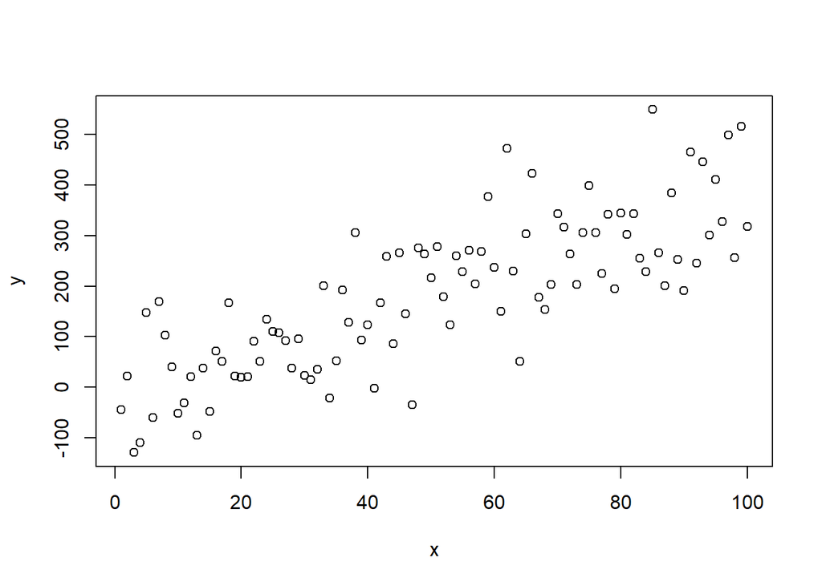

```r
x<-data1$x

y<-data1$y

plot(x,y)
```

```r
regression <- lm(data1$y ~ data1$x)
print(regression)
```

```
##
## Call:
## lm(formula = data1$y ~ data1$x)
##
## Coefficients:
## (Intercept)      data1$x
##     -25.057        4.143
```

```r
summary(regression)
```

```
##
## Call:
## lm(formula = data1$y ~ data1$x)
##
## Residuals:
##      Min       1Q   Median       3Q      Max
## -204.635  -69.680   -1.799   59.514  240.761
##
## Coefficients:
##             Estimate Std. Error t value Pr(>|t|)
## (Intercept) -25.0568    18.3020  -1.369    0.174
## data1$x       4.1435     0.3146  13.169   <2e-16 ***
## ---
## Signif. codes:  0 '***' 0.001 '**' 0.01 '*' 0.05 '.' 0.1 ' ' 1
##
## Residual standard error: 90.82 on 98 degrees of freedom
## Multiple R-squared:  0.6389, Adjusted R-squared:  0.6353
## F-statistic: 173.4 on 1 and 98 DF,  p-value: < 2.2e-16
```

## QUIZ QUESTIONS

1. Based on the simple linear regression model, which is the value of the least square estimator for $B_{0}$

```r
print("The intercept (B0) is -25.056...")
```

```
## [1] "The intercept (B0) is -25.056..."
```

```r
print("B1 is 4.14")
```

```
## [1] "B1 is 4.14"
```

3. Based on:
   $$\begin{align*}
   H_{0}:B_{0} = 0
   \end{align*}$$
   $$\begin{align*}
   H_{1}:B_{0} \neq 0
   \end{align*}$$
   what can we conclude?
- Failed to reject the null hypothesis at $alpha$ = 0.05
- Failed to reject the null hypothesis at $alpha$ = 0.01
4. Based on:
   $$\begin{align*}
   H_{0}:B_{1} = 0
   \end{align*}$$
   $$\begin{align*}
   H_{1}:B_{1} \neq 0
   \end{align*}$$
   what can we conclude?
- Reject the null hypothesis at $alpha$ = 0.05

# SUMMATIVE QUIZ

1. Given 7 data points $(x_{1},y_{1}),...(x_{7},y_{7})$ with $\sum{x} = 38,\sum{y}=89, \sum{x^{2}} = 270, \sum{y^{2}} = 1147, \sum{xy} = 495$ fin the values of $\hat{B_{0}}$ and $\hat{B_{1}}$.

```r
n = 7
xy = 495
sum_y = 89
sum_x = 38
sum_x2 = 270
sum_y2 = 1147
sum_xy = 495

# Find SXX , SXY, SYY

SXX = sum_x2 - ((sum_x)^2/n)
SXY = sum_xy - ((sum_x * sum_y)/n)
SYY = sum_y2-(sum_y/n)

# Find B0 and B1

B1 = SXY/SXX
```